# Lab 7 Solution

Monash University, Econ & Bus Stat, ETC3250/5250

prepared by Professor Di Cook

Materials for Week 7

# Class discussion

The focus this week is understanding how to determine the importance of variables in tree and forest models.

*Question 1: In the following tree, what would you says is the order of importance of the variables for classifying region?*

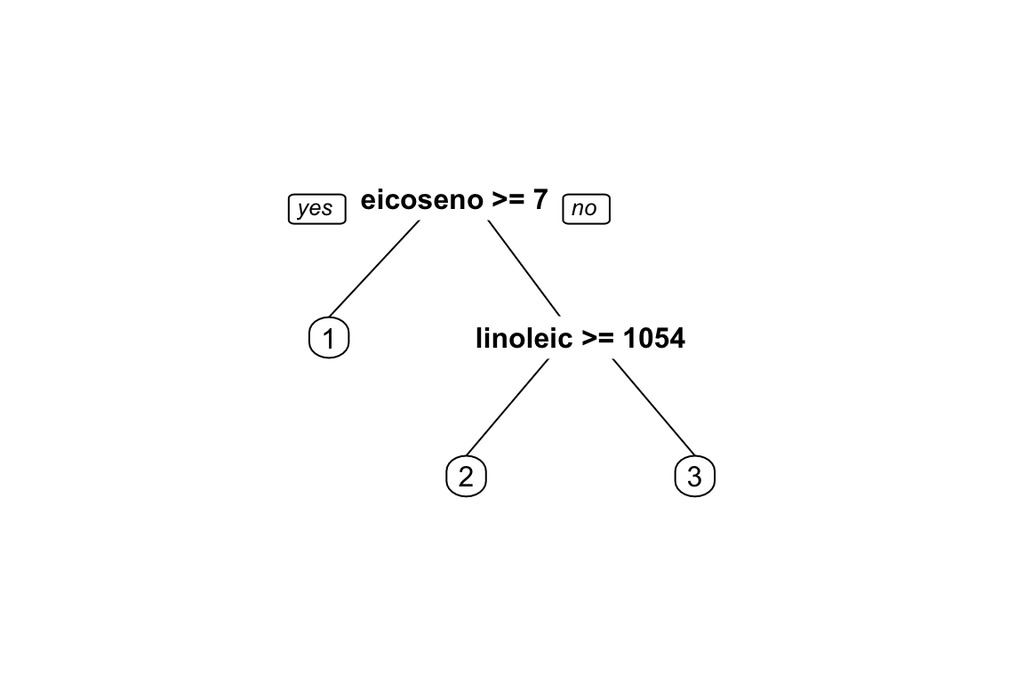

**Top of the tree is most important.**

*Question 2: Read the explanation of how variable importance is calculated from the original developers of the algorithm (Leo Breiman and Adele Cutler), at https://www.stat.berkeley.edu/~breiman/RandomForests/cc_home.htm. Make a sketch to explain how this permutation approach can be used to measure variable importance.*

**Something like this below. If the permuted variable does worse than the actual variable in separating the classes, then the variable is considered to be important. Not shown in this diagram is that only out-of-bag cases are used.**

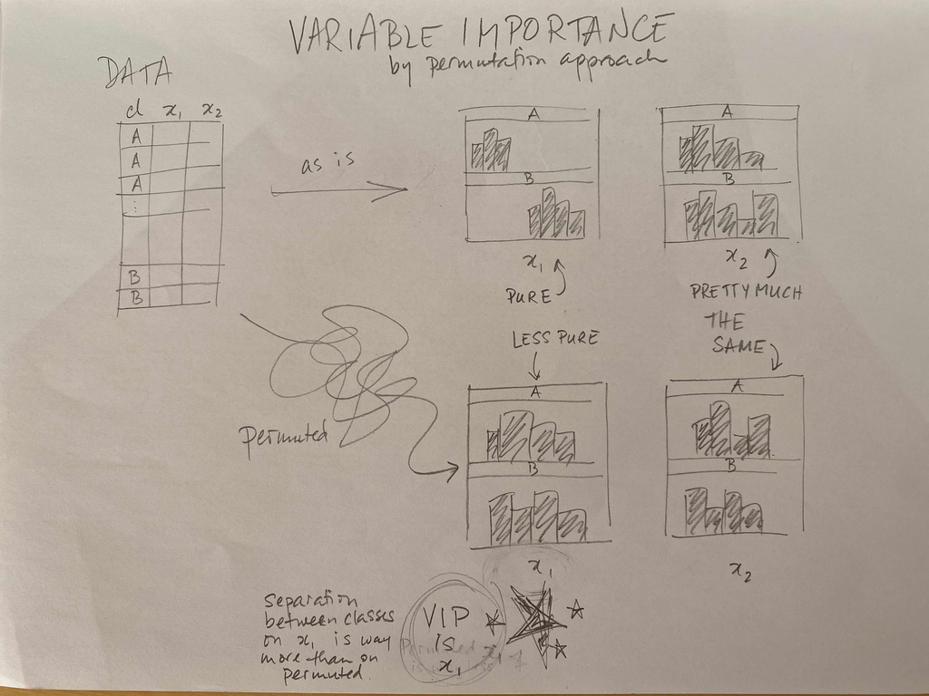

# Practice

1. Fit the tree to olive oils, using a training split of 2/3, using only regions 2, 3, and the predictors linoleic and arachidic. Report the training and test error, and make a plot of the boundary.

```
# Accuracy
#        0
#   Accuracy
# 0.01234568
```

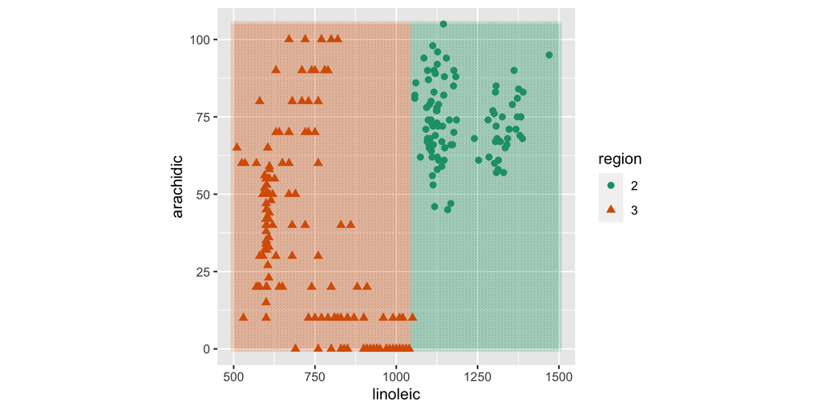

2. Fit a random forest to the full data, using only linoleic and arachidic as predictors, report the out-of-bag error, and make a plot of the boundary.

```
#
# Call:
#  randomForest(formula = region ~ ., data = olive_sub, importance = TRUE)
#                Type of random forest: classification
#                      Number of trees: 500
# No. of variables tried at each split: 1
#
#         OOB estimate of  error rate: 0%
# Confusion matrix:
#    2   3 class.error
# 2 98   0           0
# 3  0 151           0
```

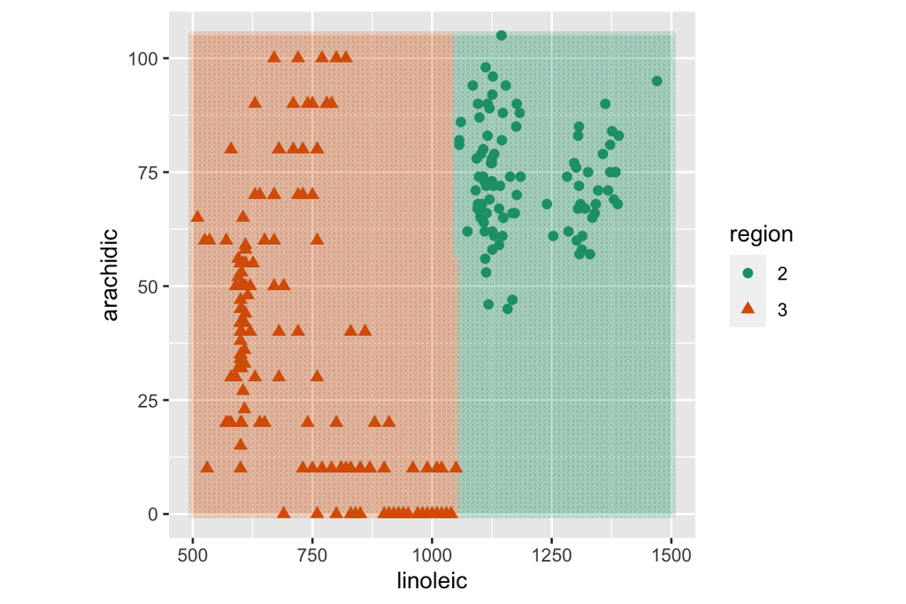

3. Explain the difference between the single tree and random forest boundaries.

**The random forest makes a small l-shape in the boundary that allows it to better capture the difference between groups. Its a very small change.**

4. Fit the random forest again to the full set of variables, and compute the variable importance. Describe the order of importance of variables.

```
#
# Call:
#  randomForest(formula = region ~ ., data = olive, importance = TRUE)
#                Type of random forest: classification
#                      Number of trees: 500
# No. of variables tried at each split: 2
#
#         OOB estimate of  error rate: 0%
# Confusion matrix:
#    2   3 class.error
# 2 98   0           0
# 3  0 151           0
#                         2            3 MeanDecreaseAccuracy MeanDecreaseGini
# palmitic     6.201296e-03 0.0014379784         3.308227e-03        1.5004802
# palmitoleic  1.251152e-02 0.0080258716         9.780941e-03        5.3855391
# stearic      1.832261e-02 0.0032159991         9.083142e-03        2.9723542
# oleic        2.743528e-01 0.1068586362         1.716261e-01       42.1517807
# linoleic     3.145757e-01 0.1706523172         2.261581e-01       44.6474290
# linolenic    5.628296e-02 0.0176726008         3.265775e-02        7.3087267
# arachidic    5.973604e-02 0.0161886015         3.318951e-02       14.2631284
# eicosenoic  -9.286749e-05 0.0001100443         1.525958e-05        0.0803326
```

5. Create a new variable called `linoarch` that is $0.377 \times linoleic + 0.926\times arachidic$. Make a plot of this variable against arachidic. Fit the tree model to the same training data using this variable in addition to linoleic and arachidic. Check the test error too. Why doesn’t the tree use this new variable? It has a bigger difference between the two groups than linoleic?

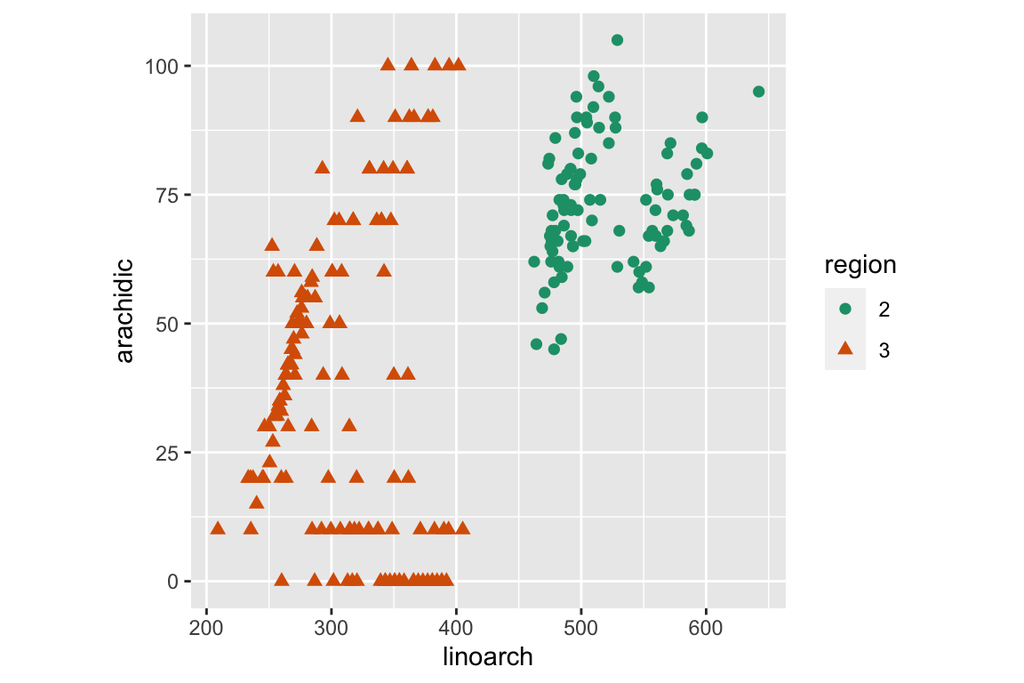

```
# n= 168
#
# node), split, n, loss, yval, (yprob)
#       * denotes terminal node
#
# 1) root 168 66 3 (0.3928571 0.6071429)
#   2) linoleic>=1043.5 66  0 2 (1.0000000 0.0000000) *
#   3) linoleic< 1043.5 102  0 3 (0.0000000 1.0000000) *
#   Accuracy
# 0.01234568
# n= 168
#
# node), split, n, loss, yval, (yprob)
#       * denotes terminal node
#
# 1) root 168 66 3 (0.3928571 0.6071429)
#   2) linoarch>=432.025 66  0 2 (1.0000000 0.0000000) *
#   3) linoarch< 432.025 102  0 3 (0.0000000 1.0000000) *
# Accuracy
#        0
```

**The algorithm sees linoleic before it sees linoarch, and it uses this. To force the tree to ignore linoleic it needs to be removed. The test error for the tree based on linoarch is 0.**

6. Fit the random forest again to the full set of variables, including linoarch and compute the variable importance. Describe the order of importance of variables. Does the forest see the new variable?

```
#
# Call:
#  randomForest(formula = region ~ ., data = olive, importance = TRUE)
#                Type of random forest: classification
#                      Number of trees: 500
# No. of variables tried at each split: 3
#
#         OOB estimate of  error rate: 0%
# Confusion matrix:
#    2   3 class.error
# 2 98   0           0
# 3  0 151           0
#                        2            3 MeanDecreaseAccuracy MeanDecreaseGini
# palmitic    0.0003115199 7.345013e-05         0.0001719538      0.145917964
# palmitoleic 0.0032280837 7.487353e-04         0.0016882545      2.100269731
# stearic     0.0019928514 3.703704e-05         0.0008195552      0.374416311
# oleic       0.1570529115 6.555207e-02         0.1008766391     27.421799401
# linoleic    0.2163308557 1.278656e-01         0.1615589270     36.948294181
# linolenic   0.0186460748 3.252407e-03         0.0092414040      2.448275006
# arachidic   0.0202489734 3.348176e-03         0.0099205202      7.396838312
# eicosenoic  0.0000500000 0.000000e+00         0.0000212766      0.001127742
# linoarch    0.2533328653 1.509769e-01         0.1903285321     41.585358540
```

**The variable importance shows that the forest can see linoarch as an important variable.**

7. This last question is see how random forests can be used in really tough problems. We use a forest to analyse the happy paintings by Bob Ross. This was the subject of the [538 post](http://fivethirtyeight.com/features/a-statistical-analysis-of-the-work-of-bob-ross/), “A Statistical Analysis of the Work of Bob Ross”.

We have taken the painting images from the [sales site](http://www.saleoilpaintings.com/paintings/bob-ross/bob-ross-sale-3_1.html), read the images into R, and resized them all to be 20 by 20 pixels. Each painting has been classified into one of 8 classes based on the title of the painting. This is the data that you will work with.

It is provided in wide and long form. Long form is good for making pictures of the original painting, and the wide form is what you will need to use for fitting the classification models. In wide form, each row corresponds to one painting, and the rgb color values at each pixel are in each column. With a $20\times20$ image, this leads to $400\times3=1200$ columns.

Here are three of the original paintings in the collection, labelled as “scene”, “water”, “flowers”:

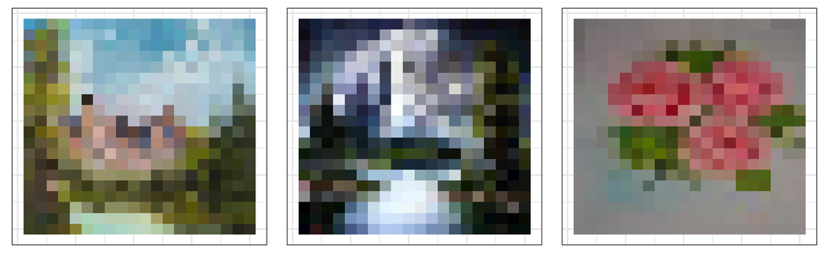

1. How many paintings in the training data? Explain the difference between the long and the wide format of the data. What is the dimension of the data, used for the classification? **178 paintings. The images are 20x20 which generates 400 variables but 3 colour channels gives 1200 variables. Long format is useful for plotting the painting as an image, but the forest needs wide form to do the fit.**
2. Build a random forest for the training data, for two classes, `flowers` and `cold`.
3. Predict the class of test set, report the error.**no error**
4. Which pixels are the most important for distinguishing these two types of paintings? **b317 is the variable that is most important. To decode this in terms of pixels, you need to look in the long for data, to row 317. It is pixel, (17,16 ) and the blue component of colour.**